# Estadisticas de uso de suelo en zonas con subsidencia

Katia Michelle Villarnobo

19/11/2021

### Descripcción

*Este código muestra una serie de gráficas que muestran áreas afectadas por subsidencia en función del uso de suelo*

#### *Librerías*

```r
library(dplyr)
```

```r
library(ggplot2)
library(readxl)
library(extrafont)
```

### Insumos

*La base de datos utilizada contiene información de peligro asociado a subsidencia en función del tipo de uso del suelo para cada municipio. La base de datos se obtuvo intersectando la capa de uso de suelo por Sentinel 2 [(CONABIO, 2018)] (https://monitoreo.conabio.gob.mx/snmb_charts/descarga_datos_madmex.html), la cual se categorizó en las siguientes clases; áreas urbanas, áreas agrícolas y otros usos de la tierra, con la capa de peligro asociada a subsicdencia, la cual fue categorizada previamente en 4 clases según los siguientes rangos; > 0 cm sin hundimiento, -1 cm a -2 cm hundimiento bajo, de -2,1 cm a -4 cm hundimiento moderado, -4,1 cm a -6 cm de hundimiento alto y> 6 cm de hundimiento muy alto.*

```r
## Importar la base de datos
Uso_Suelo <- read_xlsx("Base_datos_suelo_Municipios.xlsx", sheet = 1 )
```

#### Porcentaje de uso de suelo presente en la zona de estudio en función del peligro

*Para cuantificar las áreas afectadas por subsidencia de cada municipio se generó una nueva base de datos en la que se calculó el porcentaje de área afectada en cada municipio.*

```r
nueva_base_1 <- (Uso_Suelo[,c("Descripcci", "Peligro", "NOMGEO", "Shape_Area")])


Area_tot <- nueva_base_1 %>%  group_by(NOMGEO)


Area_tot <- Area_tot %>% summarise(
  Area_km = sum(Shape_Area)
)

Base_Final<- merge(nueva_base_1, Area_tot, by ="NOMGEO")

## Calculate the percentage of subsidence zones in each municipality

Base_Final$Por_Area<- Base_Final$Shape_Area*100/Base_Final$Area_km
```

### Gráfica 1: Porcentaje de uso del suelo para cada municipio en la zona de estudio.

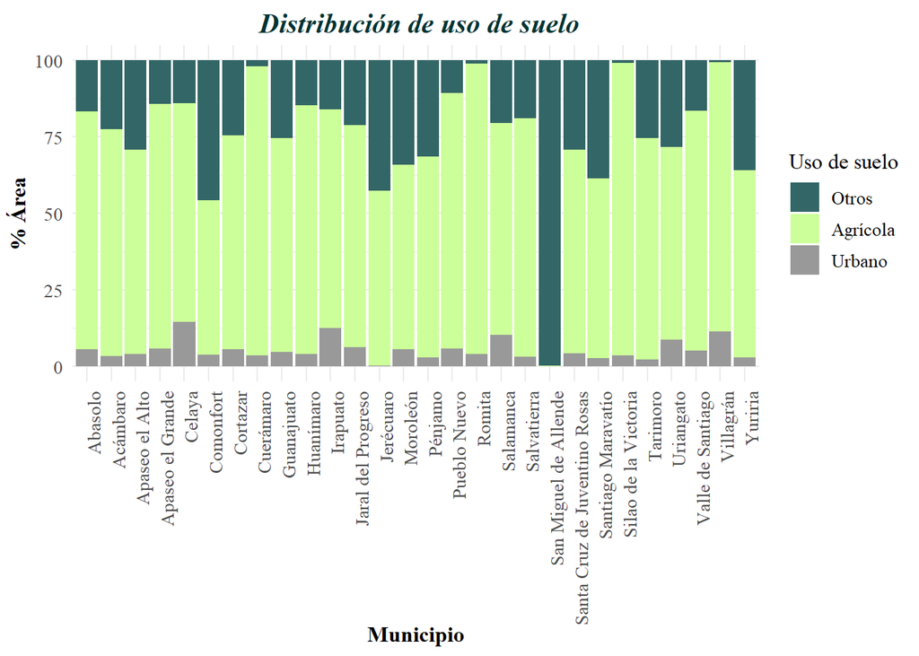

```r
Grafica_P_Uso_Suelo <- ggplot(Base_Final, aes(NOMGEO, Por_Area, fill= factor(Descripcci, levels = c("Otros", "Agrícola", "Urbano"))))

Grafica_P_Uso_Suelo<- Grafica_P_Uso_Suelo + geom_bar(position = 'stack', stat="identity" ) +
  labs(x = "Municipio",y = "% Área")+
  ggtitle (" Distribución de uso de suelo")  +

  scale_fill_manual(breaks = c("Otros", "Agrícola", "Urbano"),
                    values=c("#336666", "#CCFF99", "#999999") )
## Estilo de los ejes

Grafica_P_Uso_Suelo<- Grafica_P_Uso_Suelo+ theme_minimal()+ theme(axis.text=element_text(size=10, family="serif"),
                                                  axis.title=element_text(size=12,face="bold", family="serif"), plot.title = element_text(hjust = 0.5))

## Formato del título

Grafica_P_Uso_Suelo<-Grafica_P_Uso_Suelo+ theme (plot.title = element_text(family="serif",
                                                                   size= 15,
                                                                   vjust=0.5,
                                                                   hjust =0.5,
                                                                   face="bold.italic",
                                                                   color="#003333",
                                                                   lineheight=1.5))
## leyenda

Grafica_P_Uso_Suelo<- Grafica_P_Uso_Suelo+ theme(legend.title=element_text(size=12, family="serif"), axis.text.x = element_text(size=10, angle = 90, hjust = 1), legend.text=element_text(size=10, family="serif"))+ labs(fill = "Uso de suelo")

## Muestra la gráfica
Grafica_P_Uso_Suelo
```

### Gráfica 2: Distribución de Uso de Suelo en la zona de estudio.

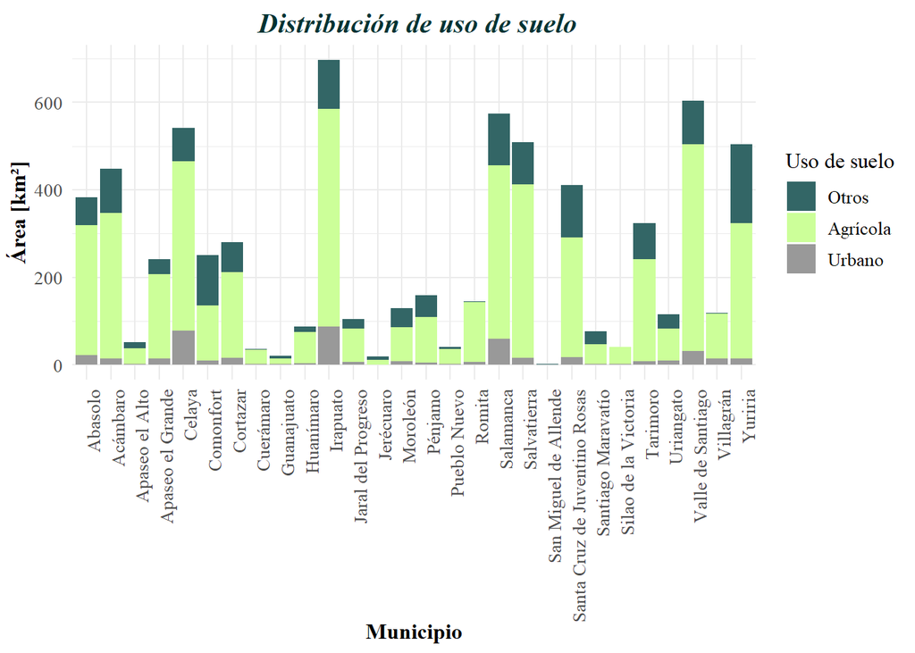

```r
Grafica_Uso_Suelo_km <- ggplot(Base_Final, aes(NOMGEO, Shape_Area, fill= factor(Descripcci, levels = c("Otros", "Agrícola", "Urbano"))))

Grafica_Uso_Suelo_km <- Grafica_Uso_Suelo_km  + geom_bar(position = 'stack', stat="identity" ) +
labs(x = "Municipio",y = "Área [km²]")+
  ggtitle (" Distribución de uso de suelo")  +

  scale_fill_manual(breaks = c("Otros", "Agrícola", "Urbano"),
                    values=c("#336666", "#CCFF99", "#999999") )
## Estilo de los ejes

Grafica_Uso_Suelo_km <- Grafica_Uso_Suelo_km + theme_minimal()+ theme(axis.text=element_text(size=10, family="serif"),
                                                  axis.title=element_text(size=12,face="bold", family="serif"), plot.title = element_text(hjust = 0.5))

## Formato del título

Grafica_Uso_Suelo_km <-Grafica_Uso_Suelo_km + theme (plot.title = element_text(family="serif",
                                                                   size= 15,
                                                                   vjust=0.5,
                                                                   hjust =0.5,
                                                                   face="bold.italic",
                                                                   color="#003333",
                                                                   lineheight=1.5))
## Leyenda

Grafica_Uso_Suelo_km <- Grafica_Uso_Suelo_km + theme(legend.title=element_text(size=12, family="serif"), axis.text.x = element_text(size=10, angle = 90, hjust = 1), legend.text=element_text(size=10,family="serif"))+ labs(fill = "Uso de suelo")

## Muestra la gráfica
Grafica_Uso_Suelo_km
```

### Crear una nueva base de datos para identificar zonas afectadas por subsidencia y áreas sin subsidencia

```r
### Crear una categoría binaria  asignando 0 a las zonas afectadas y 1 a zonas no afectadas.


Uso_suelo_bin<-mutate(Uso_Suelo, VALOR = ifelse(Uso_Suelo$Peligro!= 'Nulo',0,1) )
```

### Base de datos 2: zonas agrícolas

```r
AGRICOLA <- Uso_suelo_bin %>% filter(Descripcci == 'Agrícola')

AGRICOLA_base_1 <- (AGRICOLA[,c("Descripcci", "Peligro", "NOMGEO", "Shape_Area", "VALOR")])


AGRICOLA_Area_tot <- AGRICOLA %>%  group_by(NOMGEO)


Area_tot <- AGRICOLA_Area_tot %>% summarise(
  Area_km = sum(Shape_Area)
)

AGRICOLA_Final<- merge(AGRICOLA_base_1, Area_tot, by ="NOMGEO")

## ## Calcular el porcentaje de zonas con subsidencia para cada municipio con uso de suelo agrícola
AGRICOLA_Final$Por_Area<- AGRICOLA_Final$Shape_Area*100/AGRICOLA_Final$Area_km
```

### Graph 3: Porcentaje de subsidencia en zonas agrícolas

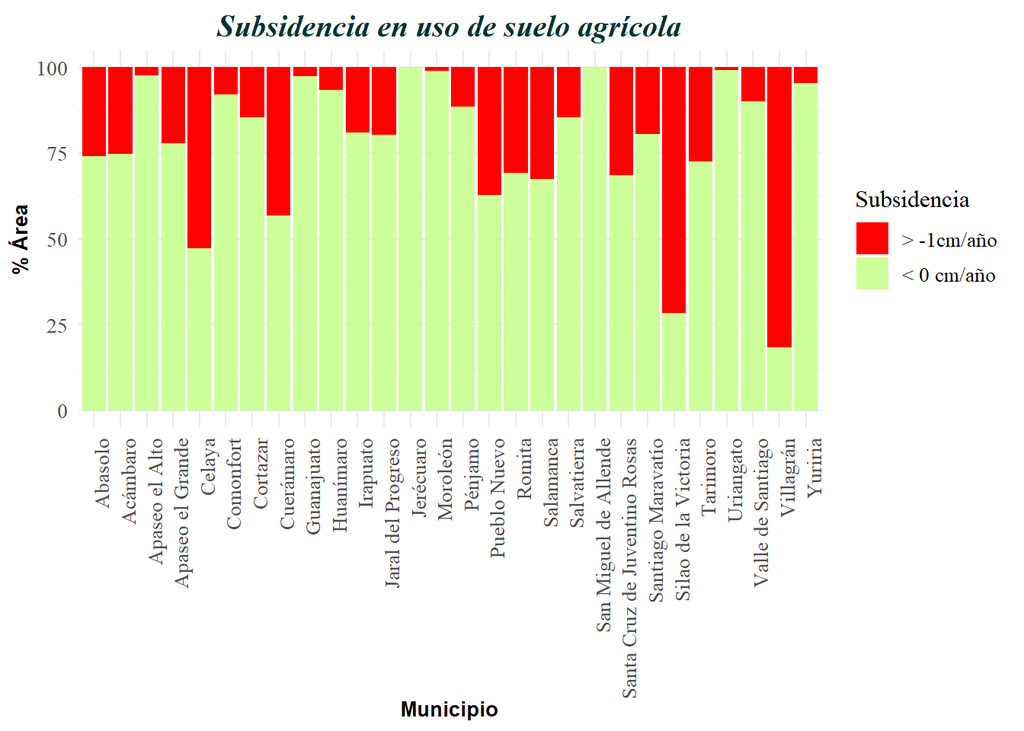

```r
Grafica_P_Agricola <- ggplot(AGRICOLA_Final, aes(NOMGEO, Por_Area, fill= factor(VALOR, levels = c("0", "1"))))

Grafica_P_Agricola <- Grafica_P_Agricola  + geom_bar(position = 'stack', stat="identity" ) +
  labs(x = "Municipio",y = "% Área")+
  ggtitle ("Subsidencia en uso de suelo agrícola")  +

  scale_fill_manual(breaks = c("0", "1"),
                    values=c("#FF0000", "#CCFF99"), labels=c("> -1cm/año", "< 0 cm/año ") )
## Estilo de los ejes

Grafica_P_Agricola <- Grafica_P_Agricola + theme_minimal()+ theme(axis.text=element_text(size=10, family="serif"),
                                                  axis.title=element_text(size=10,face="bold"), plot.title = element_text(hjust = 0.5))

## Formato del título

Grafica_P_Agricola <-Grafica_P_Agricola + theme (plot.title = element_text(family="serif",
                                                                   size= 15,
                                                                   vjust=0.5,
                                                                   hjust =0.5,
                                                                   face="bold.italic",
                                                                   color="#003333",
                                                                   lineheight=1.5))
## Leyenda

Grafica_P_Agricola <- Grafica_P_Agricola + theme(legend.title=element_text(size=12, family="serif"), axis.text.x = element_text(size=10, angle = 90, hjust = 1), legend.text=element_text(size=10, family="serif"))+ labs(fill = "Subsidencia")

## Muestra la gráfica
Grafica_P_Agricola
```

### Graph 4: Áreas afectadas en zonas agrícolas

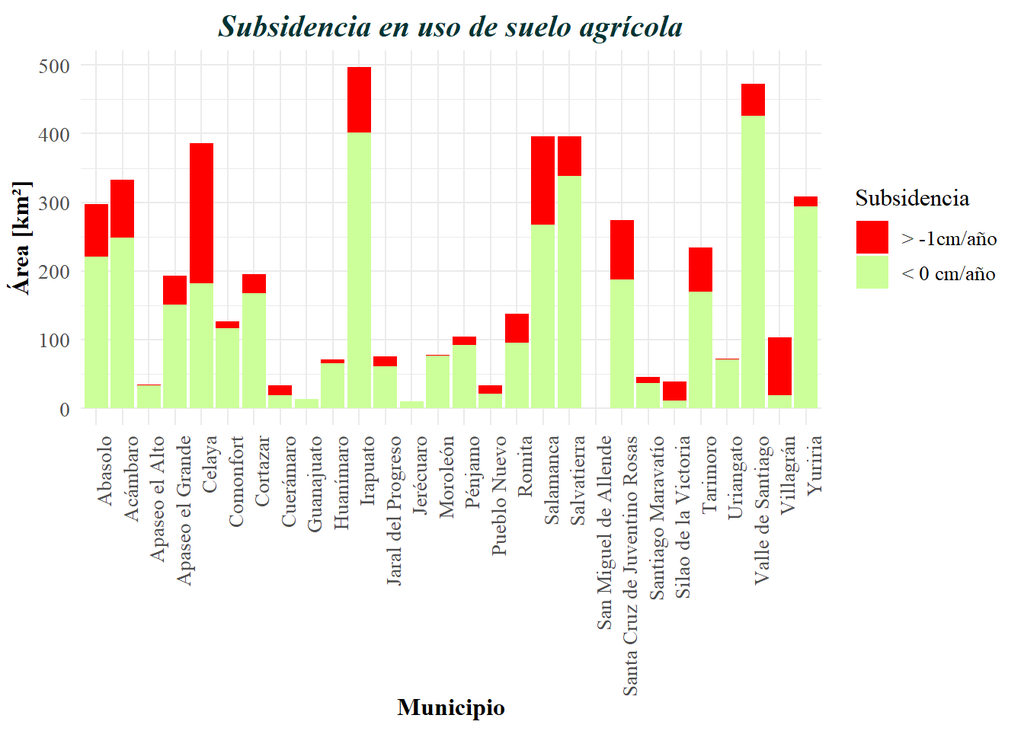

```r
Agricultural_km <- ggplot(AGRICOLA_Final, aes(NOMGEO, Shape_Area, fill= factor(VALOR, levels = c("0", "1"))))

Agricultural_km<- Agricultural_km+ geom_bar(position = 'stack', stat="identity" ) +
  labs(x = "Municipio",y = "Área [km²]")+
  ggtitle ("Subsidencia en uso de suelo agrícola")  +

  scale_fill_manual(breaks = c("0", "1"),
                    values=c("#FF0000", "#CCFF99"), labels=c("> -1cm/año", "< 0 cm/año ") )
## Estilo de los ejes

Agricultural_km<- Agricultural_km+ theme_minimal()+ theme(axis.text=element_text(size=10, family="serif"),
                                                  axis.title=element_text(size=12,face="bold", family="serif"), plot.title = element_text(hjust = 0.5))

## Formato del título

Agricultural_km<-Agricultural_km+ theme (plot.title = element_text(family="serif",
                                                                   size= 15,
                                                                   vjust=0.5,
                                                                   hjust =0.5,
                                                                   face="bold.italic",
                                                                   color="#003333",
                                                                   lineheight=1.5))
## Leyenda

Agricultural_km<- Agricultural_km+ theme(legend.title=element_text(size=12, family="serif"), axis.text.x = element_text(size=10, angle = 90, hjust = 1), legend.text=element_text(size=10, family="serif"))+ labs(fill = "Subsidencia")

##Muestra la gráfica
Agricultural_km
```

### Base de datos 3: Zonas Urbanas

```r
URBANO  <- Uso_suelo_bin %>% filter(Descripcci == 'Urbano')


URBANO_base_1 <- (URBANO[,c("Descripcci", "Peligro", "NOMGEO", "Shape_Area", "VALOR")])


URBANO_Area_tot <- URBANO %>%  group_by(NOMGEO)


Area_tot <- URBANO_Area_tot %>% summarise(
  Area_km = sum(Shape_Area)
)

URBANO_Final<- merge(URBANO_base_1, Area_tot, by ="NOMGEO")

## Calcular el porcentaje de zonas con subsidencia para cada municipio con uso de suelo urbano

URBANO_Final$Por_Area<- URBANO_Final$Shape_Area*100/URBANO_Final$Area_km
```

### Gráfica 5: Porcentaje de subsidencia en zonas urbanas

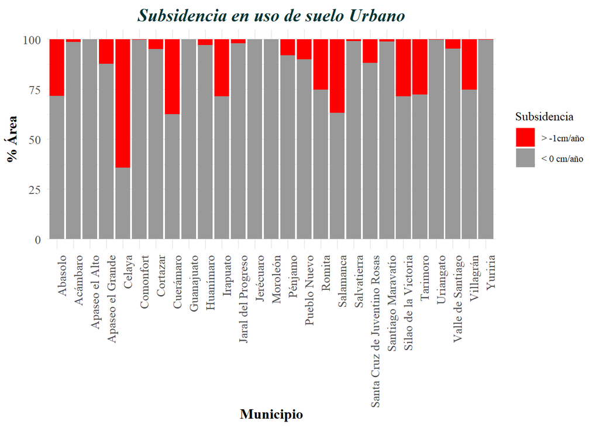

```r
Grafica_Urbano_P <- ggplot(URBANO_Final, aes(NOMGEO, Por_Area, fill= factor(VALOR, levels = c("0", "1"))))

Grafica_Urbano_P<- Grafica_Urbano_P + geom_bar(position = 'stack', stat="identity" ) +
  labs(x = "Municipio",y = "% Área")+
  ggtitle ("Subsidencia en uso de suelo Urbano")  +

  scale_fill_manual(breaks = c("0", "1"),
                    values=c("#FF0000", "#999999"), labels=c("> -1cm/año", "< 0 cm/año ") )
## Estilo de los ejes

Grafica_Urbano_P<- Grafica_Urbano_P+ theme_minimal()+ theme(axis.text=element_text(size=10, family="serif"),
                                                  axis.title=element_text(size=12,face="bold", family="serif"), plot.title = element_text(hjust = 0.5))

## Formato del título

Grafica_Urbano_P<-Grafica_Urbano_P+ theme (plot.title = element_text(family="serif",
                                                                 size= 15,
                                                                 vjust=0.5,
                                                                 hjust =0.5,
                                                                 face="bold.italic",
                                                                 color="#003333",
                                                                 lineheight=1.5))
## Leyenda

Grafica_Urbano_P<- Grafica_Urbano_P+ theme(legend.title=element_text(size=10, family="serif"), axis.text.x = element_text(size=10, angle = 90, hjust = 1), legend.text=element_text(size=8, family="serif"))+ labs(fill = "Subsidencia")

### Muestra la gráfica
Grafica_Urbano_P
```

### Gráfica 6: Áreas afectadas en zonas urbanas

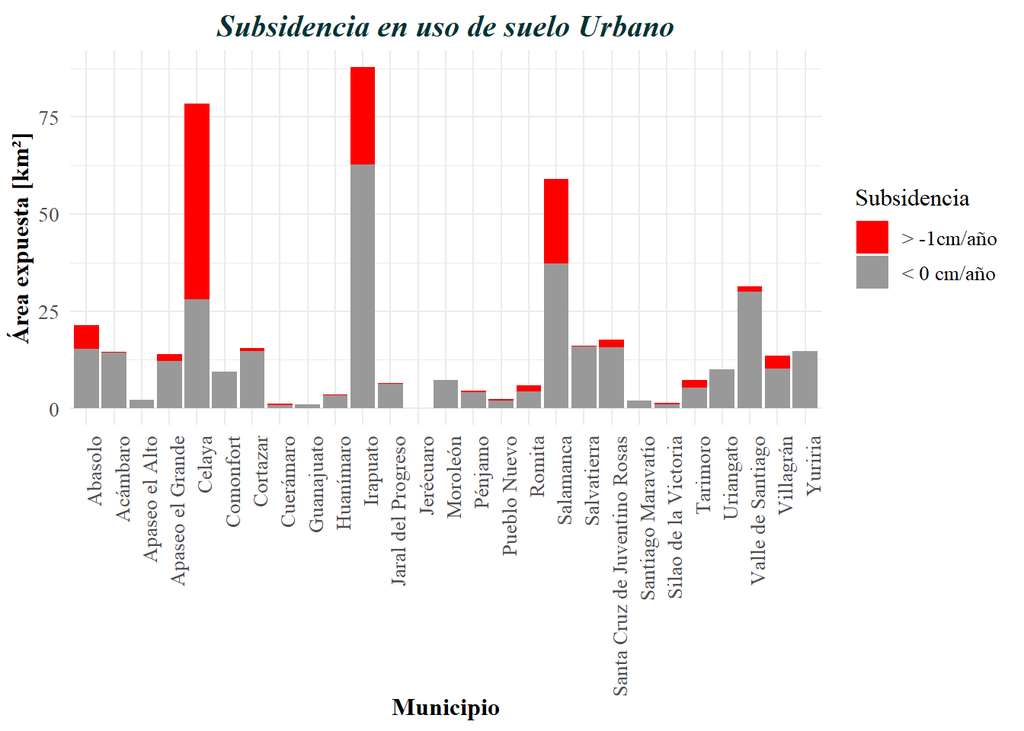

```r
Grafica_Urbano <- ggplot(URBANO_Final, aes(NOMGEO, Shape_Area, fill= factor(VALOR, levels = c("0", "1"))))

Grafica_Urbano<- Grafica_Urbano + geom_bar(position = 'stack', stat="identity" ) +
  labs(x = "Municipio",y = "Área expuesta [km²]")+
  ggtitle ("Subsidencia en uso de suelo Urbano")  +

  scale_fill_manual(breaks = c("0", "1"),
                    values=c("#FF0000", "#999999"), labels=c("> -1cm/año", "< 0 cm/año ") )
## Estilo de los ejes

Grafica_Urbano<- Grafica_Urbano+ theme_minimal()+ theme(axis.text=element_text(size=10, family="serif"),
                                                  axis.title=element_text(size=12,face="bold", family="serif"), plot.title = element_text(hjust = 0.5))

## Formato deltítulo

Grafica_Urbano<-Grafica_Urbano+ theme (plot.title = element_text(family="serif",
                                                                   size= 15,
                                                                   vjust=0.5,
                                                                   hjust =0.5,
                                                                   face="bold.italic",
                                                                   color="#003333",
                                                                   lineheight=1.5))
## Leyenda

Grafica_Urbano<- Grafica_Urbano+ theme(legend.title=element_text(size=12, family="serif"), axis.text.x = element_text(size=10, angle = 90, hjust = 1), legend.text=element_text(size=10, family="serif"))+ labs(fill = "Subsidencia")


# Muestra la gráfica

Grafica_Urbano
```